# American Time Use Survey: Analytical Exploration

- Show All Code
- Hide All Code

Time Allocation, Trends, and Comparisons

Author

Maxwell Taylor

Published

November 25, 2026

This notebook serves as the initial analitical workspace for exploring patterns in the American Time Use Survey (ATUS) from 2003 to 2025.

It builds upon the data preperation and exploration completed in `explore_atus.ipynb`. The objective is to identify patterns, compare visualizations, and investigate potential directions for the final visual narrative.

## 1 Data Preparation

### 1.1 Packages and Data Sources

Import the processed respondent-level dataset and reference tables created during the initial data exploration.

**Load R packages and processed datasets**

```r
# Load packages
library(tidyverse)
library(ggplot2)
library(ggthemes)
library(plotly)

options(
  jupyter.display_mimetypes = c(
    "text/plain",
    "text/html",
    "text/markdown",
    "image/png",
    "image/svg+xml"
  )
)

# Load prepared respondant-level data
atus_full <- readRDS("data/processed/atus_full.rds")

# Load reference tables
activity_inventory <- readRDS("data/processed/activity_inventory.rds")
activity_profile <- readRDS("data/processed/activity_profile.rds")
resp_inventory <- readRDS("data/processed/resp_inventory.rds")
```

### 1.2 Survey Year Selection and Weights

Exclude 2020 from annual comparisons due to interrupted data collection during the COVID-19 pandemic.

Use the ATUS final survey weight (`TUFNWGTP`) when calculating population-level estimates to account for differenes in representation across respondents.

**Filter survey years and verify weights**

```r
atus_analysis <- atus_full |>
  # As mentioned in explore_atus, 2020 is missing data due to the pandemic
  filter(TUYEAR != 2020)

# Verify survey weights by year as described on
# https://www.bls.gov/tus/other-documentation/howto.htm
weight_check <- atus_analysis |>
  group_by(TUYEAR) |>
  summarize(
    n = n(),
    missing_weights = sum(is.na(TUFNWGTP)),
    nonpositive_weights = sum(TUFNWGTP <= 0, na.rm = TRUE),
    min_weights = min(TUFNWGTP, na.rm = TRUE),
    max_weight = max(TUFNWGTP, na.rm = TRUE),
    .groups = "drop"
  )

weight_check
```

### 1.3 First-tier Activity Aggregation

ATUS activity codes are organized into three hierarchical levels. The first two digits identify the broad activity category.

Aggregate the individual six-digit activity variables into the 17 major activity categories, plus unclassified time (`code_50`)

Each resulting column represents the total number of minutes a respondent spent on that category during their diary day.

**Group activity codes by first-tier category**

```r
# Group activity codes by tier
tier1_codes <- split(
  activity_inventory$code,
  activity_inventory$tier_1
)

# Examine results
names(tier1_codes)
# Analysis\Data\Raw\lexiconnoex0325.pdf
# Unclear why no 17
# 50 means "unable to code"

tier1_codes[["01"]] # ALL personal care activity codes
tier1_codes[["02"]] # All household activity codes
# etc.
```

**Check for missing and negative activity durations**

```r
# Check data completeness
activity_profile |>
  filter(n_missing > 0 | n_negative > 0) # 0 rows, so complete
```

**Aggregate respondent-level activity durations**

```r
# Respondent-level activity summary

# Retain respondent characteristics
atus_tier1 <- atus_analysis |>
  select(
    # Using Analysis\Data\Raw\atuscpscodebk0325.pdf,
    # Analysis\Data\Raw\atusintcodebk0325.pdf,
    # Analysis\Data\Raw\atusintcodebk0325.interview.pdf
    TUCASEID, # Respondant ID
    TUYEAR, # Year
    TUFNWGTP, # ATUS Final Weight
    TEAGE, # Age
    TESEX, # Sex
    PEEDUCA, # Highest Education
    TELFS, # Labor Force Status
    TESCHENR, # School Enrolment
    TUDIARYDAY # Day of the week, 1 = sunday
  )

# Calculate total minutes for each broad activity category
for (code in names(tier1_codes)) {
  column_name <- paste0("code_", code)
  atus_tier1[[column_name]] <- rowSums(
    atus_analysis |>
      select(all_of(tier1_codes[[code]]))
  )
}

dim(atus_tier1)
head(atus_tier1)
# ID, Year, Weight, et., + total per tier
```

### 1.4 Data Validation

Verify that the aggregated activity durations sum to 1,440 minutes for each respondent, corresponding to the 24-hour diary period.

Also verify that all retained respondents have valid survey weights and that activity durations contain no missing or negative values.

**Verify that each diary contains 1,440 minutes**

```r
# Validate via 24 hours = 1,440 minutes
tier1_columns <- paste0("code_", names(tier1_codes))

atus_tier1 <- atus_tier1 |>
  mutate(
    total_minutes = rowSums(pick(all_of(tier1_columns)))
  )

summary(atus_tier1$total_minutes) # All = 1440, correct

atus_tier1 |>
  count(total_minutes, sort = TRUE)
```

[output not shown]

### 1.5 Annual Weighted Summaries

Calculate weighted mean daily durations for each first-tier activity category, grouped by survey year.

These population-level estimates include respondents who recorded zero minutes for a given activity.

**Calculate annual weighted mean activity durations**

```r
# Annual time allocation
annual_tier1 <- atus_tier1 |>
  group_by(TUYEAR) |>
  summarise(
    across(
      all_of(tier1_columns),
      ~ weighted.mean(.x, TUFNWGTP) # "~" = short anonymous function so can use weight not just mean,
      # .x = currenty activity column, TUFNWGTP = survey weights
    ),
    .groups = "drop"
  )

annual_tier1
```

### 1.6 Activity Labels and Reshpaing

Reshape the annual summary into long format, with one observation per activity per year.

Convert minutes to hours where appropriate and associate each activity code with a readable label based on the ATUS Activity Coding guide.

**Define descriptive labels for first-tier activity codes**

```r
# Activity labels
tier1_labels <- tribble(
  # so can construct row by row vs column by column
  ~activity, ~activity_label,
  "code_01", "Personal care",
  "code_02", "Household activities",
  "code_03", "Care for household members",
  "code_04", "Care for non-household members",
  "code_05", "Work and work-related activities",
  "code_06", "Education",
  "code_07", "Consumer purchases",
  "code_08", "Professional and personal care services",
  "code_09", "Household services",
  "code_10", "Government services and civic obligations",
  "code_11", "Eating and drinking",
  "code_12", "Socializing, relaxing, and leisure",
  "code_13", "Sports, exercise, and recreation",
  "code_14", "Religious and spiritual activities",
  "code_15", "Volunteer activities",
  "code_16", "Telephone calls",
  "code_18", "Travel",
  "code_50", "Unclassified activities"
)
```

**NoteATUS Activity Code Reference**

The following table contains the shortened activity labels used throughout this notebook.

A tibble: 18 × 2

| activity <chr> | activity_label <chr> |
| --- | --- |
| code_01 | Personal care |
| code_02 | Household activities |
| code_03 | Care for household members |
| code_04 | Care for non-household members |
| code_05 | Work and work-related activities |
| code_06 | Education |
| code_07 | Consumer purchases |
| code_08 | Professional and personal care services |
| code_09 | Household services |
| code_10 | Government services and civic obligations |
| code_11 | Eating and drinking |
| code_12 | Socializing, relaxing, and leisure |
| code_13 | Sports, exercise, and recreation |
| code_14 | Religious and spiritual activities |
| code_15 | Volunteer activities |
| code_16 | Telephone calls |
| code_18 | Travel |
| code_50 | Unclassified activities |

**Reshape annual summaries into longer format and join activity labels**

```r
# Mutate for easier visualization and join labels:
annual_tier1_long <- annual_tier1 |>
  pivot_longer(
    cols = all_of(tier1_columns),
    names_to = "activity",
    values_to = "mean_minutes"
  ) |>
  mutate(
    mean_hours = mean_minutes / 60
  ) |>
  left_join(tier1_labels, by = "activity")

head(annual_tier1_long)
dim(annual_tier1_long)

# Check for unmatched activity codes
sum(is.na(annual_tier1_long$activity_label))
```

## 2 Broad Activity Analysis (Tier 1)

### 2.1 Overall Time Allocation

Investigating how daily time is distributed across the 17 major ATUS activity categories + unlcassified time.

**Extract annual activity durations for 2025**

```r
tier1_2025 <- annual_tier1_long |>
  filter(TUYEAR == 2025)

tier1_2025
```

**Plot the seven largest activity categories in 2025**

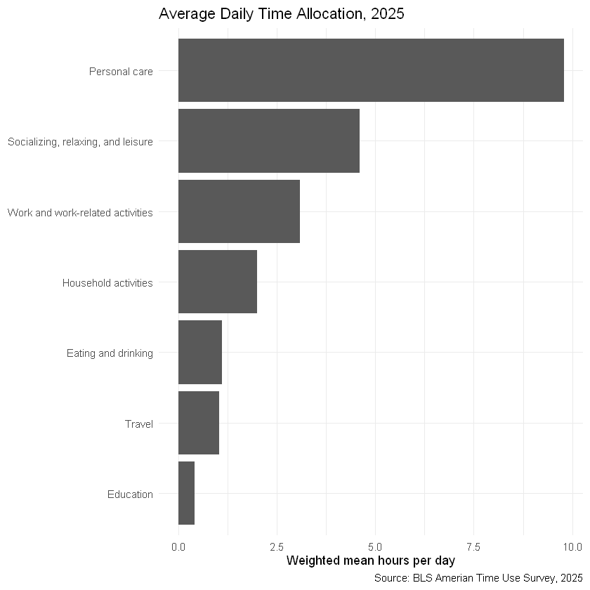

```r
# Visualization 1A: Single-year time allocation
tier1_2025 |>
  slice_max(order_by = mean_hours, n = 7, with_ties = FALSE) |>
  ggplot(
    aes(x = mean_hours, y = reorder(activity_label, mean_hours))
  ) +
  geom_col() +
  labs(
    title = "Average Daily Time Allocation, 2025",
    x = "Weighted mean hours per day",
    y = NULL,
    caption = "Source: BLS Amerian Time Use Survey, 2025"
  ) +
  theme_minimal()
```

**Compare activity durations across selected years**

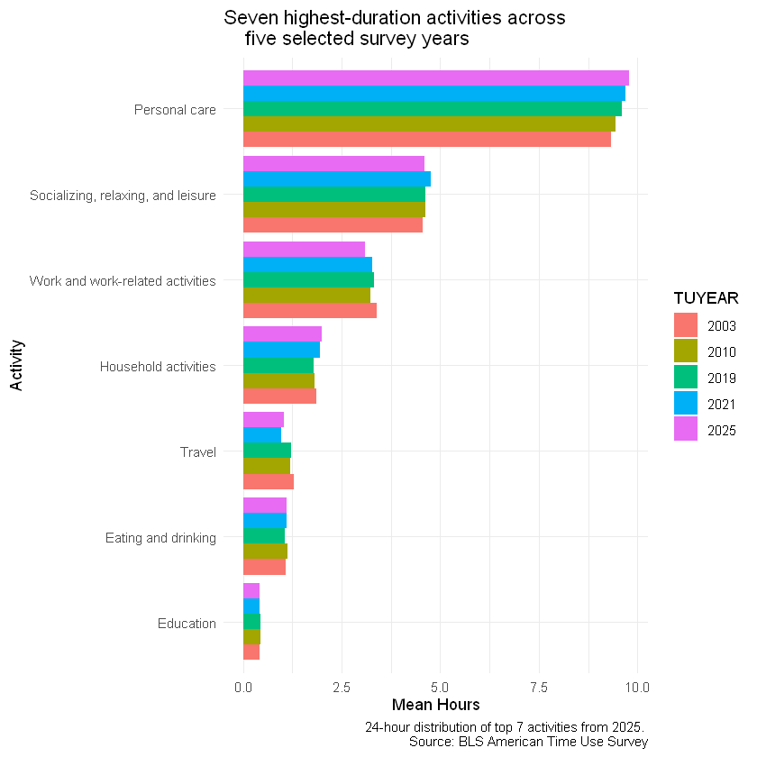

```r
# Visualization 1B: Comparison between years
tier1_selected_years <- annual_tier1_long |>
  filter(TUYEAR %in% c(2003, 2010, 2019, 2021, 2025)) |>
  mutate(
    TUYEAR = factor(TUYEAR)
  )

top_categories <- tier1_selected_years |>
  group_by(activity_label) |>
  summarize(total_val = mean(mean_hours)) |>
  slice_max(order_by = total_val, n = 7, with_ties = FALSE) |>
  pull(activity_label)


tier1_selected_years |>
  filter(activity_label %in% top_categories) |>
  ggplot(
    aes(x = mean_hours, y = reorder(activity_label, mean_hours), fill = TUYEAR)
  ) +
  geom_col(position = "dodge") +
  labs(
    title = "Seven highest-duration activities across
    five selected survey years",
    x = "Mean Hours",
    y = "Activity",
    caption = "24-hour distribution of top 7 activities from 2025.
    Source: BLS American Time Use Survey"
  ) +
  theme_minimal()
```

### 2.2 Historical Trends

Investigate how much average daily time spent in each first-tier activity category has changed from 2003 to 2025. (2020 is excluded because of interrupted data collection)

**Plot faceted historical trends for each activity**

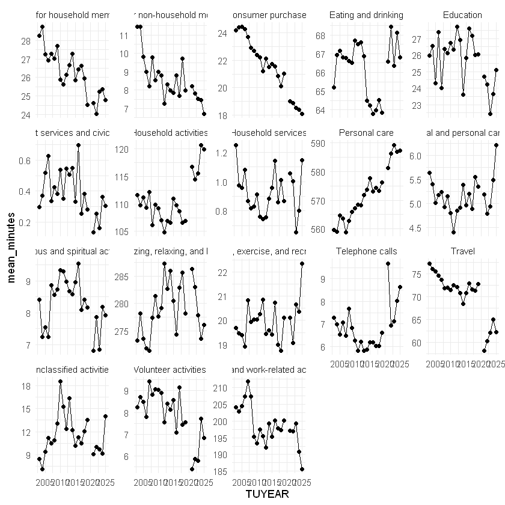

```r
# Visualization 2A: Individual activity trends

# Don't graph a line between 2019 & 2021
annual_tier1_trends <- annual_tier1_long |>
  mutate(
    period = if_else(
      TUYEAR < 2020,
      "Pre-2020",
      "Post-2020"
    )
  )

ggplot(
  annual_tier1_trends,
  aes(x = TUYEAR, y = mean_minutes, group = interaction(activity, period))
) +
  geom_line() +
  geom_point() +
  facet_wrap(~activity_label, scales = "free_y") +
  theme_minimal()
```

**Create an interactive comparison of historical trends**

```r
# Visualization 2B: Interactive historical trends
tier1_trends_plot <- ggplot(
  mutate(
    # So that legend is easily readable side by side with relavent data
    annual_tier1_trends,
    TUYEAR = as.numeric(as.character(TUYEAR)),
    activity_label = fct_reorder2(
      activity_label,
      TUYEAR,
      mean_minutes,
      .desc = TRUE
    )
  ),
  aes(
    x = TUYEAR,
    y = mean_minutes,
    group = interaction(activity, period),
    color = activity_label,
    text = paste0(
      "Activity: ",
      activity_label,
      "<br>Year: ",
      TUYEAR,
      "<br>Minutes per day: ",
      round(mean_minutes, 2),
      "<br>Hours per day: ",
      round(mean_hours, 2)
    )
  )
) +
  geom_line() +
  geom_point() +
  labs(
    title = "Average Daily Time Allocation by Year",
    x = "Year",
    y = "Mean minutes per day",
    color = "Activity",
    caption = "Select activities to compare"
  ) +
  # So that not implying continuous by rainbow default:
  scale_color_tableau(palette = "Tableau 20") +
  theme_minimal()

ggplotly(
  tier1_trends_plot,
  tooltip = "text"
) |>
  layout(
    hovermode = "closest",
    legend = list(
      traceorder = "normal",
      orientation = "v"
    ),
    xaxis = list(rangeslider = list(visible = TRUE))
  )
```

[interactive chart not shown]

### 2.3 Absolute and Relative Changes

Compare changes in daily time allocations using both absolute differences in minutes and relative differences from an established baseline.

Use 2003 as the initial exploratory baseline.

**Calculate absolute, percentage, and indexed changes for 2003**

```r
# Calculate change over time
annual_tier1_indexed <- annual_tier1_trends |>
  group_by(activity) |>
  # Chronologically order observations within each activity:
  arrange(TUYEAR, .by_group = TRUE) |>
  mutate(
    baseline_minutes = first(mean_minutes), # First annual mean per activity
    absolute_change = mean_minutes - baseline_minutes,
    percent_change = if_else(
      baseline_minutes > 0,
      (mean_minutes - baseline_minutes) / baseline_minutes * 100,
      NA_real_
    ),
    index_value = percent_change + 100
  ) |>
  ungroup()

annual_tier1_indexed |>
  filter(
    # Check change from 2003 -> 2025 for code_01
    activity == "code_01",
    TUYEAR %in% c(2003, 2025)
  )
```

**Calculate endpoint changes between 2003 and 2025**

```r
# Endpoint comparison
tier1_changes <- annual_tier1_indexed |>
  filter(TUYEAR == 2025) |>
  select(
    activity,
    activity_label,
    baseline_minutes,
    mean_minutes,
    absolute_change,
    percent_change
  ) |>
  arrange(desc(absolute_change))

tier1_changes
```

**Plot absolute changes in daily activity durations**

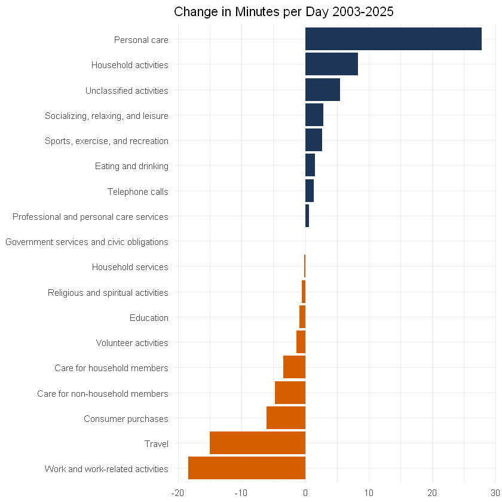

```r
# Visualization 3A: Diverging bar chart
ggplot(
  tier1_changes,
  aes(
    x = absolute_change,
    y = reorder(activity_label, absolute_change),
    fill = (absolute_change > 0)
  )
) +
  geom_col() +
  labs(
    title = "Change in Minutes per Day 2003-2025",
    x = NULL,
    y = NULL
  ) +
  scale_fill_manual(
    values = c("TRUE" = "#1d3557", "FALSE" = "#D55E00"),
    name = NULL
  ) +
  guides(fill = "none") +
  theme_minimal()
```

**Plot historical activity trends to 2003**

```r
# Visualization 3B: Indexed historical trends
index_plot <- ggplot(
  mutate(
    # So that legend is easily readable side by side with relavent data
    annual_tier1_indexed,
    TUYEAR = as.numeric(as.character(TUYEAR)),
    activity_label = fct_reorder2(
      activity_label,
      TUYEAR,
      index_value,
      .desc = TRUE
    )
  ),
  aes(
    x = TUYEAR,
    y = index_value,
    group = interaction(activity, period),
    color = activity_label,
    text = paste0(
      "Activity: ",
      activity_label,
      "<br>Year: ",
      TUYEAR,
      "<br>Absolute Change: ",
      round(absolute_change, 2),
      "<br>Percent Change: ",
      round(percent_change, 2)
    )
  )
) +
  geom_line() +
  geom_point() +
  geom_hline(
    yintercept = 100,
    linetype = "dashed",
    linewidth = 1
  ) +
  annotate(
    "label",
    x = 2008,
    y = 100,
    label = "Baseline (2003)",
    hjust = 1.1,
    vjust = -0.5,
    alpha = 0.4
  ) +
  labs(
    title = "Change in Mean Time Spent per Year",
    x = "Year",
    y = "Index",
    color = "Activity",
    caption = "Select activities to compare"
  ) +
  # So that not implying continuous by rainbow default:
  scale_color_tableau(palette = "Tableau 20") +
  theme_minimal()

ggplotly(
  index_plot,
  tooltip = "text"
) |>
  layout(
    hovermode = "closest",
    legend = list(
      traceorder = "normal",
      orientation = "v"
    ),
    xaxis = list(rangeslider = list(visible = TRUE))
  )
```

[interactive chart not shown]

**Plot a heatmap of percent changes from 2003**

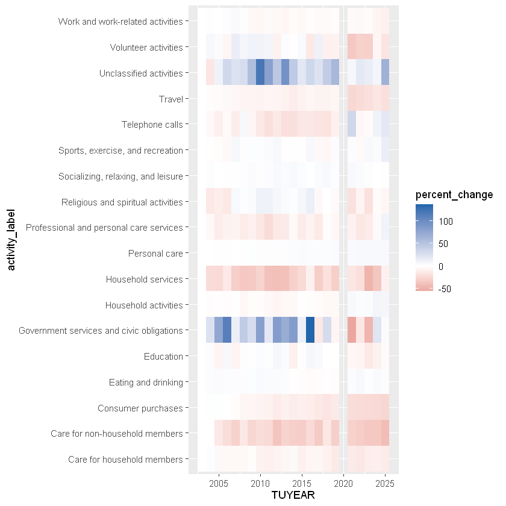

```r
# Visualization 3C: Activity-by-Year Heatmap
ggplot(
  annual_tier1_indexed,
  aes(x = TUYEAR, y = activity_label, fill = percent_change)
) +
  geom_tile() +
  scale_fill_gradient2(
    low = "#b21826",
    high = "#2166ac",
    midpoint = 0
  )
```